# Behavioral Incentives

Application: Workplace health & wellness programs

Simon Lee, Jack Taiclet, Eric Li

4/30/2024

# 1. Overview

# 2. Data Collection

We have 5 datasets covering 4,834 participants in the wellness study, each containing the following binary variables:

- **treat:** Intervention group (control=0, treated=1)
- **hra_c_yr1:** Completed 2016 Health Risk Assessment (no=0, yes=1)
- **male:** Sex of participant (female=0, male=1)
- **age50:** Age of participant (over age 50=1)
- **age37_49:** Age of participant (age 37-49=1)
- **white:** Race of participant (non-white=0, white=1)

Additional variables have date suffixes indicating the timeframe: 0715_0716 is pre-intervention; 0816_0717 is 1-year post-intervention; 0816_0119 is 2-years post-intervention.

Let’s first load some useful libraries. We add the option ‘message = FALSE’ to suppress printing the code output.

```r
library(tidyverse)
library(formattable)
library(scales)
```

Use read.csv() to load the 5 wellness datasets for analysis:

```r
#setwd("/Users/simonlee/UCLA-Grad-Courses/MGMT298/p2")
CLAIMS = read.csv("claims.csv")
FIRM = read.csv("firm_admin.csv")
MARATHON = read.csv("marathon.csv")
SURVEY = read.csv("online_surveys.csv")
PARTICIPATION = read.csv("participation.csv")
```

# 3. Data Exploration

**QUESTION 1:** Create a categorical variable for someone aged 36 or below.

```r
PARTICIPATION$age36 = if_else(PARTICIPATION$age50 == 0 & PARTICIPATION$age37_49 == 0, 1, 0)
```

Using the PARTICIPATION dataset, let’s summarize the baseline characteristics for the treated and control groups. For more details, see https://sebastiansauer.github.io/multiple-t-tests-with-dplyr/

```r
BASELINE = PARTICIPATION %>%
  select(age36, age37_49, age50, male, white, salaryQ1, salaryQ2, salaryQ3, salaryQ4, CS, faculty, AP, treat) %>%
  group_by(treat) %>%
  summarise_all(mean) %>%
  gather(variable, value, -treat) %>%
  spread(treat, value) %>%
  rename(Control = "0", Treatment = "1")

formattable(BASELINE)
```

| variable | Control | Treatment |
| --- | --- | --- |
| age36 | 0.3363755 | 0.3409091 |
| age37_49 | 0.3402868 | 0.3324242 |
| age50 | 0.3233377 | 0.3266667 |
| AP | 0.4426336 | 0.4369697 |
| CS | 0.3611473 | 0.3624242 |
| faculty | 0.1962190 | 0.2006061 |
| male | 0.4256845 | 0.4275758 |
| salaryQ1 | 0.2438070 | 0.2418182 |
| salaryQ2 | 0.2548892 | 0.2587879 |
| salaryQ3 | 0.2490222 | 0.2503030 |
| salaryQ4 | 0.2522816 | 0.2490909 |
| white | 0.8409387 | 0.8357576 |

# 4. Intervention Evaluation

**QUESTION 2:** Using the CLAIMS data, test whether average healthcare spending 1-year post-intervention (spend_0816_0717) is different between the treatment and control groups. What is your interpretation?

```r
CLAIMS$treat = as.factor(CLAIMS$treat)
t.test(spend_0816_0717 ~ treat, data = CLAIMS)
```

```
##
##  Welch Two Sample t-test
##
## data:  spend_0816_0717 by treat
## t = 0.54231, df = 1751.6, p-value = 0.5877
## alternative hypothesis: true difference in means between group 0 and group 1 is not equal to 0
## 95 percent confidence interval:
##  -81.5909 143.9548
## sample estimates:
## mean in group 0 mean in group 1
##        594.8318        563.6499
```

Answer: The t-test result does not shows a statistically significant p-value, meaning we do not have a significant difference in average healthcare spending between the treatment and control groups.

Next, let’s calculate the mean, SD, and 95% confidence interval for healthcare spending, for the treatment and control groups.

```r
SPENDING = CLAIMS %>%
  group_by(treat) %>%
  summarise(mean=mean(spend_0816_0717, na.rm=TRUE), sd=sd(spend_0816_0717, na.rm=TRUE), n=n()) %>%
  mutate(lower=mean-1.96*sd/sqrt(n), upper=mean+1.96*sd/sqrt(n))
```

**QUESTION 3:** Create a plot showing average spending, by intervention group, along with error bars for the confidence intervals. Is this consistent with the earlier t-test?

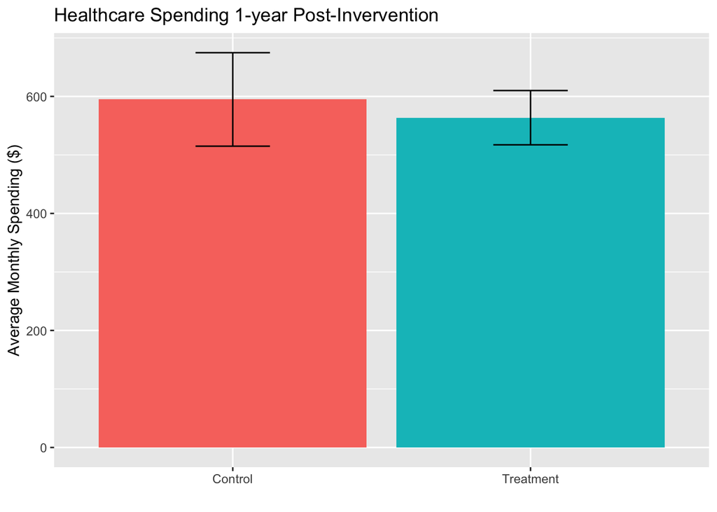

```r
# Using the SPENDING dataframe we created
ggplot(data = SPENDING, aes(x = treat, y = mean, fill = as.factor(treat))) +
  geom_col() +
  geom_errorbar(aes(ymin=lower, ymax=upper), width=0.25) +
  theme(legend.position = "none") +
  scale_x_discrete("", labels = c("0"="Control","1"="Treatment")) +
  scale_y_continuous("Average Monthly Spending ($)") +
  ggtitle("Healthcare Spending 1-year Post-Invervention")
```

The results appear to be pretty similar from before. The box plots look pretty similar meaning there was no signifcant difference.

**QUESTION 4:** Using the FIRM dataset, repeat the above analysis and plot for annual gym use one-year post-intervention. What is your interpretation?

```r
FIRM$treat = as.factor(FIRM$treat)
t.test(gym_0816_0717 ~ treat, data = FIRM)
```

```
##
##  Welch Two Sample t-test
##
## data:  gym_0816_0717 by treat
## t = 0.084121, df = 3006.5, p-value = 0.933
## alternative hypothesis: true difference in means between group 0 and group 1 is not equal to 0
## 95 percent confidence interval:
##  -1.375527  1.498845
## sample estimates:
## mean in group 0 mean in group 1
##        5.881356        5.819697
```

Answer: We do not have a significant result meaning that the program does not have impacted gym usage.

```r
GYM = FIRM %>%
  group_by(treat) %>%
  summarise(
    mean = mean(gym_0816_0717, na.rm = TRUE),  # Calculate the mean, removing NA values
    sd = sd(gym_0816_0717, na.rm = TRUE),      # Calculate the standard deviation, removing NA values
    n = n()                                        # Count the number of observations
  ) %>%
  mutate(
    lower = mean - 1.96 * sd / sqrt(n),            # Lower bound of the 95% confidence interval
    upper = mean + 1.96 * sd / sqrt(n)             # Upper bound of the 95% confidence interval
  )
```

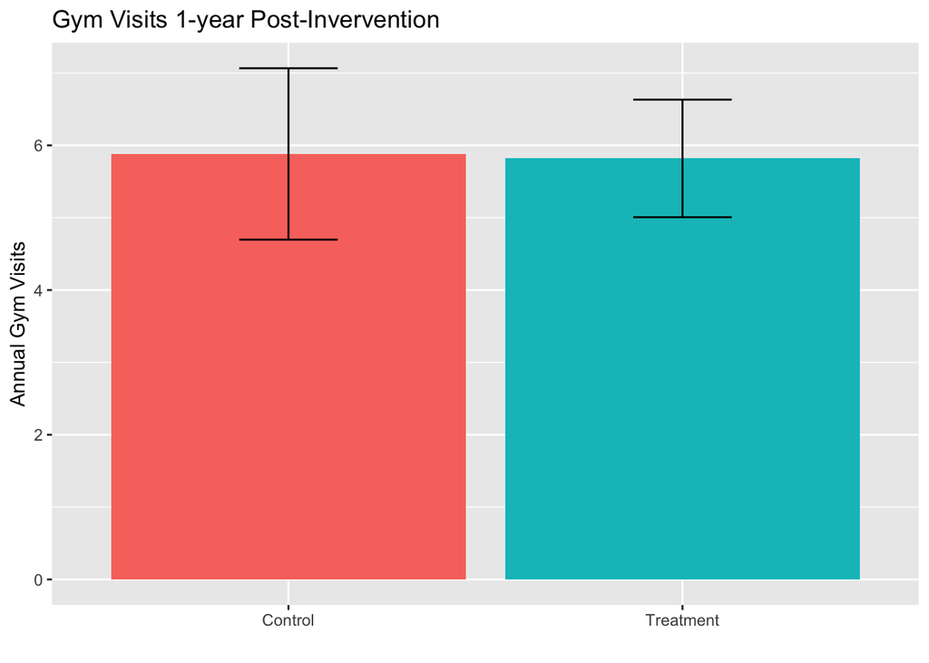

```r
ggplot(data = GYM, aes(x = treat, y = mean, fill = treat)) +
  geom_col() +
  geom_errorbar(aes(ymin=lower, ymax=upper), width=0.25) +
  theme(legend.position = "none") +
  scale_x_discrete("", labels = c("0"="Control","1"="Treatment")) +
  scale_y_continuous("Annual Gym Visits") +
  ggtitle("Gym Visits 1-year Post-Invervention")
```

**QUESTION 5:** Using the FIRM dataset, repeat the above analysis and plot for days of sick leave one-year post-intervention. What is your interpretation?

```r
t.test(sickleave_0815_0716 ~ treat, data = FIRM)
```

```
##
##  Welch Two Sample t-test
##
## data:  sickleave_0815_0716 by treat
## t = -0.37637, df = 3248.6, p-value = 0.7067
## alternative hypothesis: true difference in means between group 0 and group 1 is not equal to 0
## 95 percent confidence interval:
##  -0.5035453  0.3413608
## sample estimates:
## mean in group 0 mean in group 1
##        6.048446        6.129539
```

```r
SICK = FIRM %>%
  group_by(treat) %>%
  summarise(
    mean = mean(sickleave_0816_0717, na.rm = TRUE),
    sd = sd(sickleave_0816_0717, na.rm = TRUE),
    n = n()
  ) %>%
  mutate(
    lower = mean - 1.96 * sd / sqrt(n),
    upper = mean + 1.96 * sd / sqrt(n)
  )
```

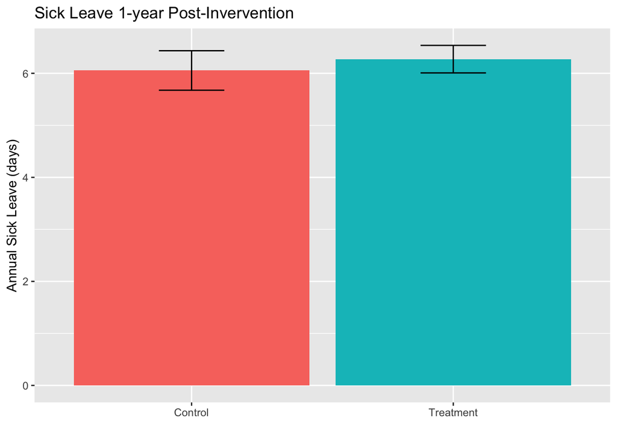

```r
ggplot(data = SICK, aes(x = treat, y = mean, fill = treat)) +
  geom_col() +
  geom_errorbar(aes(ymin=lower, ymax=upper), width=0.25) +
  theme(legend.position = "none") +
  scale_x_discrete("", labels = c("0"="Control","1"="Treatment")) +
  scale_y_continuous("Annual Sick Leave (days)") +
  ggtitle("Sick Leave 1-year Post-Invervention")
```

# 5. Adverse Selection

Here, we will examine whether the baseline characteristics differ between participants in the Treatment group who completed the Health Risk Assessment (ie, they elect to participate in the wellness program after being randomly assigned to the Treatment group).

**QUESTION 6:** Filter the CLAIMS data to include participants in the Treatment group only. Convert the variable hra_c_yr1 to a factor (categorical) variable. Then, test whether mean healthcare spending before the intervention (07/15 to 07/16) differs among those completing the HRA or not. What is your interpretation?

```r
CLAIMS_TREATED = CLAIMS %>%
  filter(treat == "1")

CLAIMS_TREATED$hra_c_yr1 = as.factor(CLAIMS_TREATED$hra_c_yr1)

t.test(spend_0715_0716 ~ hra_c_yr1, data = CLAIMS_TREATED)
```

```
##
##  Welch Two Sample t-test
##
## data:  spend_0715_0716 by hra_c_yr1
## t = 2.0749, df = 1263.1, p-value = 0.0382
## alternative hypothesis: true difference in means between group 0 and group 1 is not equal to 0
## 95 percent confidence interval:
##    5.647668 201.729137
## sample estimates:
## mean in group 0 mean in group 1
##        527.2730        423.5846
```

this is a statistically significant difference in healthcare spending before the intervention between those who completed the HRA and those who did not.

**QUESTION 7:** Calculate the mean, SD, and 95% confidence interval for healthcare spending, for the HRA and non-HRA groups. Create a plot showing average spending, by HRA group, along with error bars for the confidence intervals.

```r
SPENDING_TREATED = CLAIMS_TREATED %>%
  group_by(hra_c_yr1) %>%
  summarise(
    mean = mean(spend_0715_0716, na.rm = TRUE),
    sd = sd(spend_0715_0716, na.rm = TRUE),
    n = n()
  ) %>%
  mutate(
    lower = mean - 1.96 * sd / sqrt(n),
    upper = mean + 1.96 * sd / sqrt(n)
  )
```

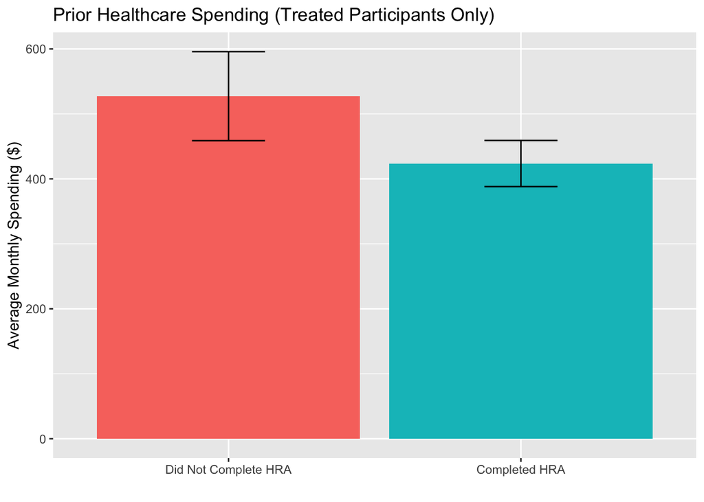

```r
ggplot(data = SPENDING_TREATED, aes(x = hra_c_yr1, y = mean, fill = hra_c_yr1)) +
  geom_col() +
  geom_errorbar(aes(ymin=lower, ymax=upper), width=0.25) +
  theme(legend.position = "none") +
  scale_x_discrete("", labels = c("0"="Did Not Complete HRA","1"="Completed HRA")) +
  scale_y_continuous("Average Monthly Spending ($)") +
  ggtitle("Prior Healthcare Spending (Treated Participants Only)")
```

**QUESTION 8:** Using the FIRM dataset, repeat the above analysis for baseline gym attendance from 08/15 to 07/16.

```r
FIRM_TREATED = FIRM %>%
  filter(treat == "1")

FIRM_TREATED$hra_c_yr1 = as.factor(FIRM_TREATED$hra_c_yr1)

t.test(gym_0815_0716 ~ hra_c_yr1, data = FIRM_TREATED)
```

```
##
##  Welch Two Sample t-test
##
## data:  gym_0815_0716 by hra_c_yr1
## t = -2.4626, df = 3257.7, p-value = 0.01385
## alternative hypothesis: true difference in means between group 0 and group 1 is not equal to 0
## 95 percent confidence interval:
##  -3.9124317 -0.4439241
## sample estimates:
## mean in group 0 mean in group 1
##        5.559917        7.738095
```

```r
GYM_TREATED = FIRM_TREATED %>%
  group_by(hra_c_yr1) %>%
  summarise(
    mean = mean(gym_0815_0716, na.rm = TRUE),
    sd = sd(gym_0815_0716, na.rm = TRUE),
    n = n()
  ) %>%
  mutate(
    lower = mean - 1.96 * sd / sqrt(n),
    upper = mean + 1.96 * sd / sqrt(n)
  )
```

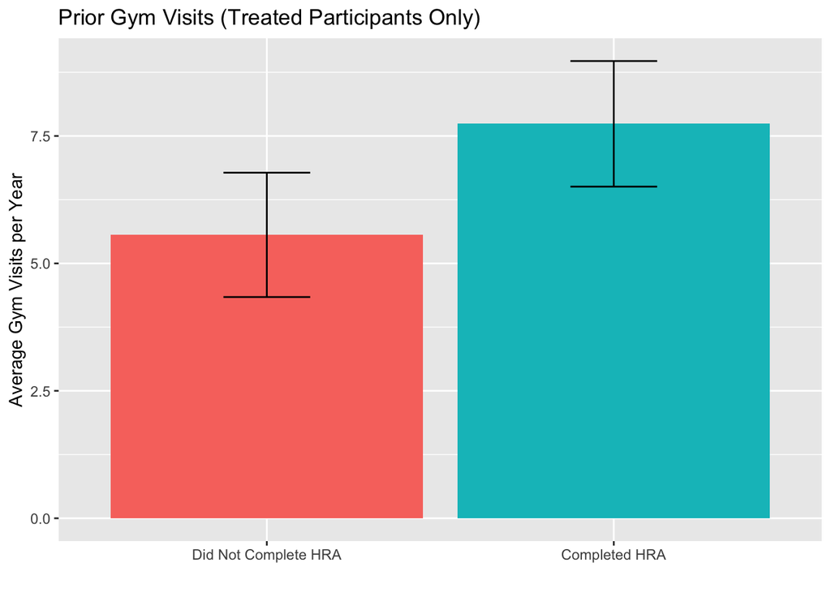

```r
ggplot(data = GYM_TREATED, aes(x = hra_c_yr1, y = mean, fill = hra_c_yr1)) +
  geom_col() +
  geom_errorbar(aes(ymin=lower, ymax=upper), width=0.25) +
  theme(legend.position = "none") +
  scale_x_discrete("", labels = c("0"="Did Not Complete HRA","1"="Completed HRA")) +
  scale_y_continuous("Average Gym Visits per Year") +
  ggtitle("Prior Gym Visits (Treated Participants Only)")
```

There is statistical significance again based on the p-value that people who completed of the HRA on gym attendance.

**QUESTION 9:** Using the MARATHON dataset, calculate the proportion of participants, by HRA group, who ran a marathon from 2014 to 2016. Test whether this is statistically significantly different. Create a plot showing marathon participation, by HRA group, along with error bars for the confidence intervals.

```r
MARATHON$hra_c_yr1 = as.factor(MARATHON$hra_c_yr1)
MARATHON$treat = as.factor(MARATHON$treat)

MARATHON_TREATED = MARATHON %>%
  filter(treat == "1") %>%
  group_by(hra_c_yr1) %>%
  summarise(runners=sum(marathon_2014_2016), n=n()) %>%
  mutate(prop=runners/n) %>%
  mutate(lower=prop-1.96*sqrt(prop*(1-prop)/n), upper=prop+1.96*sqrt(prop*(1-prop)/n))

prop.test(x = MARATHON_TREATED$runners, n = MARATHON_TREATED$n, correct = FALSE)
```

```
##
##  2-sample test for equality of proportions without continuity correction
##
## data:  MARATHON_TREATED$runners out of MARATHON_TREATED$n
## X-squared = 61.585, df = 1, p-value = 4.241e-15
## alternative hypothesis: two.sided
## 95 percent confidence interval:
##  -0.10979452 -0.06769465
## sample estimates:
##     prop 1     prop 2
## 0.06818182 0.15692641
```

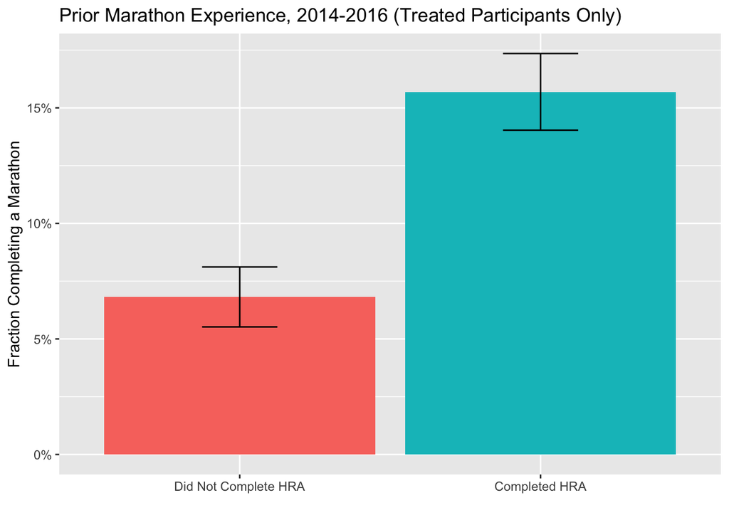

```r
ggplot(data = MARATHON_TREATED, aes(x = hra_c_yr1, y = prop, fill = hra_c_yr1)) +
  geom_col() +
  geom_errorbar(aes(ymin=lower, ymax=upper), width=0.25) +
  theme(legend.position = "none") +
  scale_x_discrete("", labels = c("0"="Did Not Complete HRA","1"="Completed HRA")) +
  scale_y_continuous("Fraction Completing a Marathon", labels = percent) +
  ggtitle("Prior Marathon Experience, 2014-2016 (Treated Participants Only)")
```

**QUESTION 10:** Based on your overall analysis, what can you conclude about this wellness program?